# Análisis de microarrays (PEC 1)

Laura Ramon

Abril 2020

# ABSTRACT

La implantación de los embriones es crucial para establecer un embarazo y requiere la interacción y sincronización entre el endometrio del útero y el embrión. Esto implica la activicion e inactivación de numerosas moléculas de señalización que pueden influir en la proliferación y diferenciación de las células epiteliales uterinas, polaridad epitelial, cierre luminal, orientación embrionaria, interacciones epiteliales-estromales, desarrollo de glándulas, etc. La progesterona, hormona secretada por el cuerpo lúteo tras la ovulación y durante toda la segunda mitad del ciclo menstrual, es clave para inducir la receptividad endometrial y favorecer la implantación del embrión en el endometrio. [1][2] Los diferentes niveles de progesterona y su tiempo de exposición dan como resultado diferentes expresiones de genes endometriales y, consecuentemente, diferencias en el potencial de implantación.

# OBJETIVOS

El objetivo de este estudio es realizar un análisis de microarrays para observar la influencia que tiene el tratamiento con progesterona y el tiempo de exposición a ella en la expresión de los diferentes genes en el endometrio. Así, se podrá determinar si un suministro extra de progesterona o una mayor exposición a ésta tras el momento de la fecundación favorece la implantación del embrión al útero.

# MATERIALES Y MÉTODOS

## Materiales

### Datos

Este análisis se aplica en un conjunto de datos de un estudio publicados por Suthaporn et al. [3] Los datos fueron subidos a la base de datos *Gene Expression Omnibus* (GEO). El conjunto de datos seleccionado se identifica con el siguiente número de acceso: GSE146777.

El experimento se basa en la comparación de diferentes muestras sin o con aporte extra de progesterona en diferentes cantidades (0.1 microM, 1 microM y 10 microM) durante un tiempo de exposición de tres, siete u once días. Así pues, el diseño del análisis es de dos factores (aporte de progesterona y tiempo de exposición) con cuatro niveles para la progesterona (sin aporte extra, aporte de 0.1 microM, aporte de 1 microM y aporte de 10 microM) y con tres niveles para el tiempo de exposición (tres días, siete días y once días).

El experimento cuenta con 24 muestras, con tres réplicas para cada grupo: tres muestras sin aporte de progesterona durante tres días, tres muestras sin aporte de progesterona durante siete días, tres muestras sin aporte de progesterona durante once días, tres muestras con aporte de 1 microM de progesterona durante tres días, tres muestras con aporte de 0.1 microM de progesterona durante siete días, tres muestras con aporte de 1 microM de progesterona durante siete días, tres muestras con aporte de 10 microM de progesterona durante 7 días y tres muestras con aporte de 1 microM de progesterona durante 11 días.

Existe un archivo .CEL para cada muestra, el cual incluye la información sobre el microarray chip correspondiente. Estos datos son de bajo nivel, puesto que son los datos binarios proporcionados por el escáner. Estos datos tendrán que pasar un control de calidad y someterse a un procesado de sumarización y normalización para pasar a ser datos de alto nivel, con los cuales ya se podrán realizar los posteriores análisis.

### Array

El array utilizado en este estudio es [Clariom_S_Human] Affymetrix Clariom S Assay, Human (Includes Pico Assay).

## Métodos

### Directorio y opciones de trabajo

Se escoge un directorio de trabajo y los datos (archivos en formato .CEL) se copian en un subdirectorio del anterior denominado *data*, mientras que también se crea otro subdirectorio denominado *results* dónde se almacenarán los resultados.

### Obtención de los datos

Los datos se obtienen mediante la descarga de los archivos almacenados en el estudio GSE146777 de la página de GEO (https://www.ncbi.nlm.nih.gov/geo/query/acc.cgi?acc=GSE146777). En concreto, se trata de 24 archivos .CEL (uno para cada muestra).

También se prepara el archivo *targets*, el cual contiene información sobre los diferentes grupos y covariables. Es decir, este archivo relaciona el nombre de cada archivo .CEL con las covariables y el grupo al cual pertenece. Estará formado por las siguientes columnas:

- *FileName*: nombre del archivo que contiene la muestra.
- *Group*: grupo al cual pertenece la muestra.
- *Timing*: tiempo durante el cual la muestra ha sido sometida al estudio.
- *Levels*: niveles de progesterona a los cuales ha sido sometida la muestra durante el tratamiento.
- *ShortName*: nombre abreviado de la muestra, compuesta por su grupo y el número de muestra dentro de este grupo.

Este archivo *targets* ha sido guardado en formato .csv, con los datos separados por punto y coma.

La siguiente tabla muestra el contenido de este archivo *targets*.

Tabla 1. Contenido del archivo targets

| FileName | Group | Timing | Levels | ShortName |
| --- | --- | --- | --- | --- |
| GSM4406818_C3_1_Clariom_S_Human_.CEL | D3.NONE | D3 | NONE | D3.NONE.1 |
| GSM4406819_C3_2_Clariom_S_Human_.CEL | D3.NONE | D3 | NONE | D3.NONE.2 |
| GSM4406820_C3_3_Clariom_S_Human_.CEL | D3.NONE | D3 | NONE | D3.NONE.3 |
| GSM4406821_C7_1_Clariom_S_Human_.CEL | D7.NONE | D7 | NONE | D7.NONE.1 |
| GSM4406822_C7_2_Clariom_S_Human_.CEL | D7.NONE | D7 | NONE | D7.NONE.2 |
| GSM4406823_C7_3_Clariom_S_Human_.CEL | D7.NONE | D7 | NONE | D7.NONE.3 |
| GSM4406824_C11-1_Clariom_S_Human_.CEL | D11.NONE | D11 | NONE | D11.NONE.1 |
| GSM4406825_C11-2_Clariom_S_Human_.CEL | D11.NONE | D11 | NONE | D11.NONE.2 |
| GSM4406826_C11-3_Clariom_S_Human_.CEL | D11.NONE | D11 | NONE | D11.NONE.3 |
| GSM4406827_D3_P1_1_Clariom_S_Human_.CEL | D3.1 | D3 | 1 | D3.1.1 |
| GSM4406828_D3_P1_2_Clariom_S_Human_.CEL | D3.1 | D3 | 1 | D3.1.2 |
| GSM4406829_D3_P1_3_Clariom_S_Human_.CEL | D3.1 | D3 | 1 | D3.1.3 |
| GSM4406830_D7_P0.1_1_Clariom_S_Human_.CEL | D7.0.1 | D7 | 0.1 | D7.0.1.1 |
| GSM4406831_D7_P0.1_2_Clariom_S_Human_.CEL | D7.0.1 | D7 | 0.1 | D7.0.1.2 |
| GSM4406832_D7_P0.1_3_Clariom_S_Human_.CEL | D7.0.1 | D7 | 0.1 | D7.0.1.3 |
| GSM4406833_D7_P1_1_Clariom_S_Human_.CEL | D7.1 | D7 | 1 | D7.1.1 |
| GSM4406834_D7_P1_2_Clariom_S_Human_.CEL | D7.1 | D7 | 1 | D7.1.2 |
| GSM4406835_D7_P1_3_Clariom_S_Human_.CEL | D7.1 | D7 | 1 | D7.1.3 |
| GSM4406836_D7_P10-1_Clariom_S_Human_.CEL | D7.10 | D7 | 10 | D7.10.1 |
| GSM4406837_D7_P10-2_Clariom_S_Human_.CEL | D7.10 | D7 | 10 | D7.10.2 |
| GSM4406838_D7_P10-3_Clariom_S_Human_.CEL | D7.10 | D7 | 10 | D7.10.3 |
| GSM4406839_D11_P1_1_Clariom_S_Human_.CEL | D11.1 | D11 | 1 | D11.1.1 |
| GSM4406840_D11_P1_2_Clariom_S_Human_.CEL | D11.1 | D11 | 1 | D11.1.2 |
| GSM4406841_D11_P1_3_Clariom_S_Human_.CEL | D11.1 | D11 | 1 | D11.1.3 |

### Lectura de los datos

A continuación, se procede a realizar la lectura de los archivos .CEL. Para ello, se usa el paquete *oligo* y las funciones *list.celfiles*, *read.AnnotatedDataFrame* y *read.celfiles*.

### Exploración y visualización de los datos

Una vez leídos todos los datos, se procede a realizar el preprocesado de éstos, con la finalidad de observar el resultado del experimento mediante la realización de gráficos, la realización de un control de calidad de los datos y su normalización para el posterior análisis. Es importante que los datos sean de calidad y no tengan demasiado ruido, para poder llevar a cabo la normalización de una manera correcta.

Para ello, se usa el paquete *ArrayQualityMetrics*, el cual realiza un estudio de la calidad de los datos y muestra algunos gráficos básicos para mostrarla, como pueden ser los diagramas de caja y los gráficos PCA (*Principal Component Analysis*).

También muestra una tabla resumen con los resultados de este estudio. Las columnas *1,* 2 y *3 de la figura 1 corresponden a los distintos métodos de detección, siendo los siguientes:

- Detección de *outliers* mediante ‘Distancia entre arrays’
- Detección de *outliers* mediante ‘Boxplots’
- Detección de *outliers* mediante ‘MA plots’

Si un array está por encima de un determinado umbral, se marca con una X y es identificado como *outlier*.

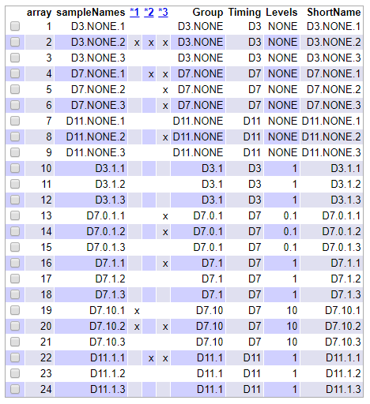

Figura 1. Descripción general del array y detección de outliers

En la figura 1, se puede observar que el array 2 es identificado como *outlier* en los tres métodos, los arrays 4, 20 y 22 en dos métodos, y los arrays 5, 6, 8, 13, 14, 16 y 19 en un método.

A continuación, se profundiza más en el estudio de estos *outliers* mediante los distintos gráficos producidos.

**Distancia entre arrays**

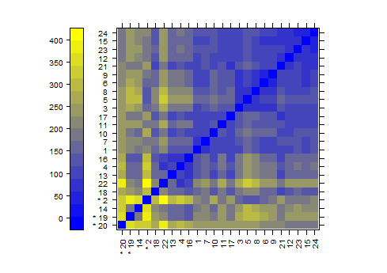

Figura 2. Heatmap de las distancias entre arrays

La figura 2 muestra un *heatmap* de las distancias entre arrays. Los patrones en este gráfico pueden indicar la agrupación de los arrays, debida a factores experimentales biológicos o no. La distancia entre dos conjuntos se calcula como la diferencia absoluta media entre los datos de los arrays. La detección de *outliers* se realiza buscando arrays para los cuales la suma de las distancias a todos los demás arrays es muy grande. Se han detectado tres de estos arrays, los cuales son los arrays 2, 19 y 20 (marcados con un asterisco).

**Detección de outliers mediante la distancia entre arrays**

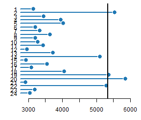

Figura 3. Gráfico de barras de la suma de las distancias a otros arrays

La figura 3 muestra un gráfico de barras de la suma de las distancias a otros arrays. El umbral determinado es de 5340, indicado mediante una línea vertical. Los arrays que han excedido este umbral y han sido considerados *outliers* son los arrays 2, 19 y 20.

**Análisis principal de componentes**

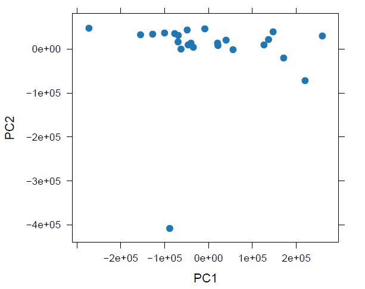

Figura 4. Diagrama de dispersión de los arrays

La figura 4 muestra un diagrama de dispersión de los arrays a lo largo de las dos primeras componentes principales. Este gráfico permite observar si hay agrupación de los arrays. Se puede observar que hay un array que está muy separado del resto, teniendo en cuenta la segunda componente principal.

Este gráfico proporcionado por el paquete *ArrayQualityMetrics* no proporciona suficiente información acerca del nombre y el grupo del array de la muestra, de manera que se procede a definir una función que proporcione un gráfico con esta información.

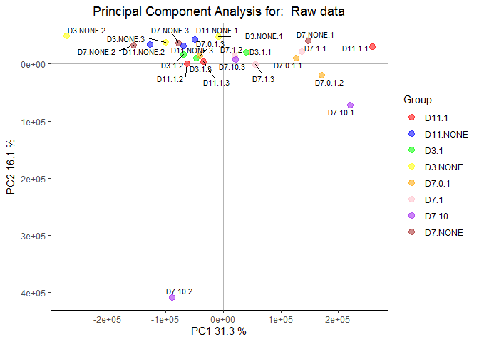

Figura 5. Diagrama de dispersión de componentes principales

En la figura 5, se observa que el array *outlier* pertenece al grupo D7.10 (aporte de 10 microM de progesterona durante siete días). También se observa que la primera componente representa el 31.3% de la variabilidad total de las muestras y la segunda componente representa el 16.1% de la variabilidad total de las muestras. No se puede observar un patrón claro sobre la contribución de las variables. Para ello, se esperará a la normalización de los datos.

**Boxplots**

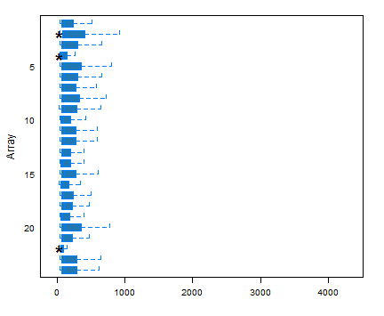

Figura 6. Boxplot de la intensidad de señales de los arrays

La figura 6 muestra un *boxplot* que representa la intensidad de señal de los arrays. Se espera que las cajas tengan posiciones y anchos similares. Una distribución muy diferente a las demás puede indicar un problema experimental.

En este gráfico, la detección de valores *outliers* se ha realizado con el estadístico de Kolmogorov-Smirnov entre la distribución de cada array y la distribución de los datos agrupados.

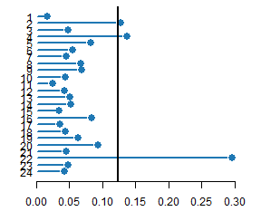

Figura 7. Detección de outliers mediante boxplots

La figura 7 muestra que los arrays detectados como outliers son los arrays 2, 4 y 22.

A continuación, se muestra otro boxplot más visual de la distribución de intensidad de los arrays de todas las muestras.

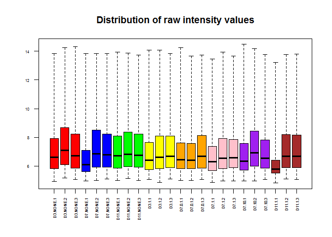

Figura 8. Boxplot de la intensidad de señales de los arrays

La figura 8 muestra un boxplot con la distribución de las intensidades de las muestras, organizadas por colores según el grupo al cual pertenecen. Se observan variaciones en la intensidad entre los arrays de las muestras, las más importantes de las cuales coinciden con las observaciones del gráfico anterior, pero es lo que cabe esperar cuando los datos aún no han sido procesados.

**Gráfico de densidad de la distribución de los arrays**

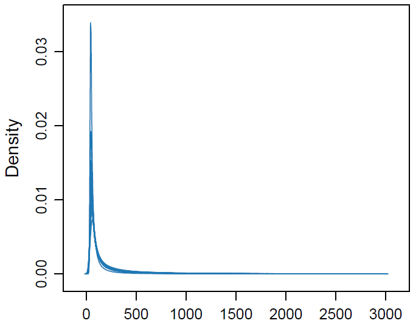

Figura 9. Gráfico de densidad de los arrays

La figura 9 muestra un gráfico de densidad con las distribuciones de los arrays. Se observa que todos los arrays muestran una distribución similar. Si no lo fueran, se podrá considerar que es debido a un problema de calidad.

**Gráfico de densidad de la desviación estándar de las intensidades versus el rango de la media**

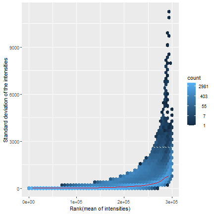

Figura 10. Gráfico de densidad de la desviación estándar de las intensidades versus el rango de la media

La figura 10 muestra un gráfico de densidad de la desviación estándar de las intensidades (eje Y) versus el rango de la media (eje X). Los puntos rojos muestran la mediana de la desviación estándar, la cual se espera que sea horizontal tras la normalización de los datos.

### Normalización

El paso siguiente a realizar es la normalización de los datos, mediante la cual se corregirá el ruido de fondo, es decir, toda la variabilidad entre muestras que no sean debidas a razones biológicas (como sesgos debidos a problemas técnicos) y se hará que los valores de los arrays sean comparables entre ellos.

El método utilizado ha sido el *Robust Multichip Analysis* (RMA). [4]

Una vez aplicado el método RMA, se realiza un control de calidad para comprobar cómo han cambiado los datos. Se usa nuevamente el paquete *ArrayQualityMetrics* para la visualización de los datos.

La figura 11 muestra que sólo el array 22 es identificado como *outlier* por dos métodos y los arrays 14 y 19 por un método.

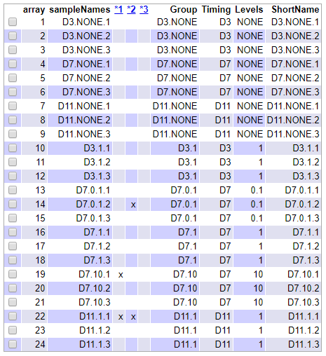

Figura 11. Descripción general del array y detección de outliers

**Distancia entre arrays**

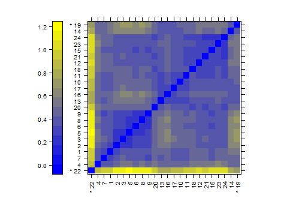

Figura 12. Heatmap de las distancias entre arrays

La figura 12 muestra el *heatmap* de las distancias entre arrays tras la normalización. Se observa que los arrays 19 y 22 podrán ser posibles *outliers*, debido a que la suma de las distancias a todos los demás arrays es muy grande.

**Detección de outliers mediante la distancia entre arrays**

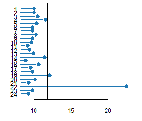

Figura 13. Gráfico de barras de la suma de las distancias a otros arrays

La figura 13 muestra el gráfico de barras de la suma de las distancias a otros arrays, con un umbral determinado en 11.8 y representado con una línea vertical. Se detectan como *outliers* los arrays 19 y 22.

Los datos anteriores a la normalización mostraban como *outliers* a los arrays 2, 19 y 20, y tras la normalización los arrays 19 y 22. Así pues, el array 19 es detectado como *outlier* en ambos casos.

**Análisis principal de componentes**

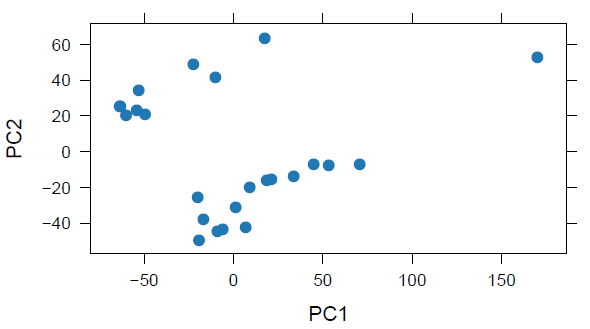

Figura 14. Diagrama de dispersión de los arrays

La figura 14 muestra el diagrama de dispersión de los arrays a lo largo de las dos primeras componentes principales. Se puede observar que, comparando con el gráfico obtenido antes de la normalización, los arrays se han agrupado de manera distinta.

Obtenemos otro gráfico de este análisis de componentes principales con más información sobre el grupo de los arrays.

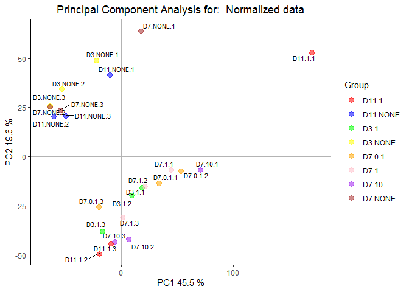

Figura 15. Diagrama de dispersión de componentes principales

**Boxplots**

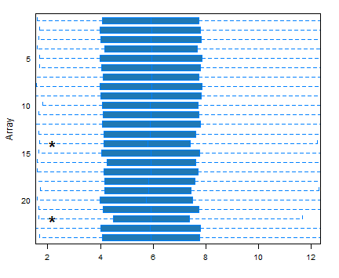

Figura 16. Boxplot de la intensidad de señales de los arrays

La figura 16 es un *boxplot* dónde las cajas representan la intensidad de los arrays.

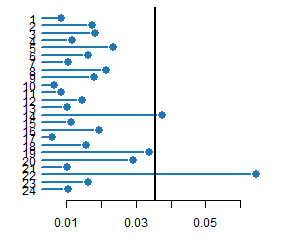

Figura 17. Detección de outliers mediante boxplots

La figura 17 detecta como *outliers*, una vez realizada la normalización, los arrays 14 y 22, mientras que previamente a la normalización se detectaron los arrays 2, 4 y 22. Así pues, el array 22 continua siendo un *outlier* según este método.

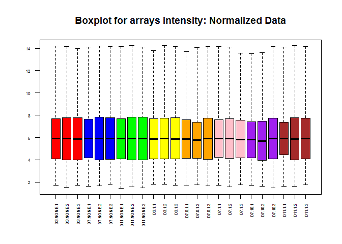

Figura 18. Boxplot de la intensidad de señales de los arrays

La figura 18 muestra un *boxplot* que representa la distribución de las intensidades normalizadas de todas las muestras, agrupadas por colores según su grupo. Se observa que todas las cajas muestran un aspecto similar, hecho que nos sugiere que el proceso de normalización ha funcionado bien. Aunque esto es lo esperado, ya que el método RMA incluye un paso llamado normalización cuantil, dónde la distribución empírica de las muestras se establece en los mismos valores.

**Gráfico de densidad de la distribución de los arrays**

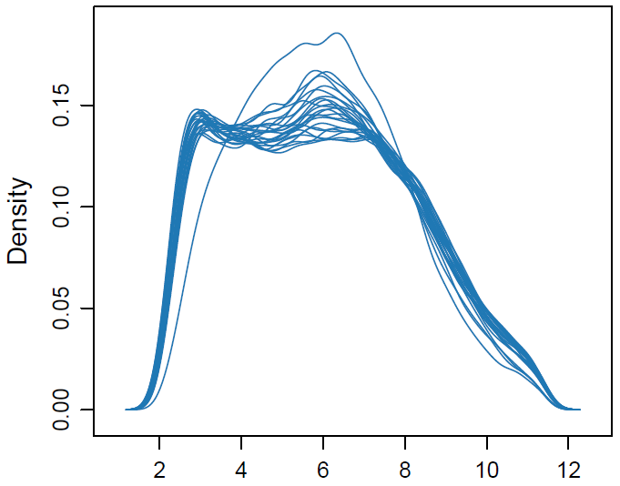

Figura 19. Gráfico de densidad de los arrays

La figura 19 muestra un gráfico de densidad con las distribuciones normalizadas de los arrays. Se observa que todas las distribuciones son similares, salvo una que se desvía un poco.

**Gráfico de densidad de la desviación estándar de las intensidades versus el rango de la media**

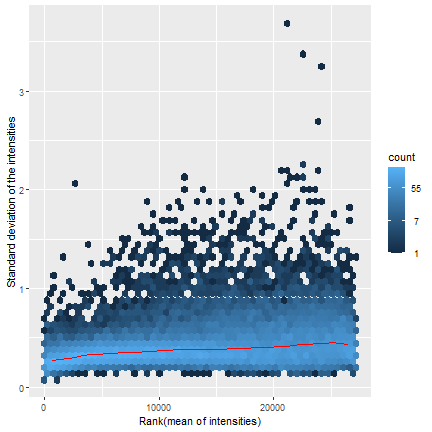

Figura 20. Gráfico de densidad de la desviación estándar de las intensidades versus el rango de la media

La figura 20 muestra el gráfico de densidad de la desviación estándar de las intensidades normalizadas versus el rango de la media. Se observa que la mediana de la desviación estándar, representada por puntos rojos, se asemeja a una línea horizontal, lo cual es lo esperado.

**Gráfico MA**

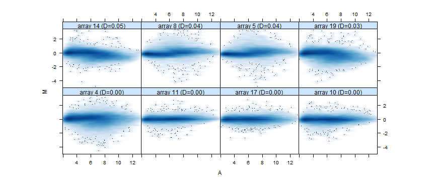

Figura 21. Gráfico MA

La figura 21 muestra un gráfico MA, en el cual se espera que la masa de distribución se concentre en el eje M=0 y no debería haber una tendencia en función de A. La detección de *outliers* se realiza mediante el cálculo del estadístico Hoeffding sobre la distribución conjunta de A y M para cada array. Este estadístico puede observarse en los encabezados de cada panel.

**Detección de outliers mediante el gráfico MA**

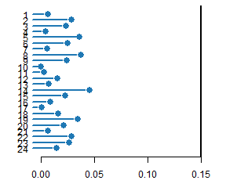

Figura 22. Detección de outliers mediante el gráfico MA

La figura 22 muestra que ninguno de los arrays ha sido detectado como *outlier*, al no ser el estadístico superior al umbral de 0.15.

A continuación, se procede a continuar el estudio con todas las muestras, ya que ninguna de ellas, tras el proceso de la la normalización, muestra ser un *outlier* por tres métodos distintos.

### Detección de factores batch

Los resultados de los microarrays pueden verse alterados por distintas razones no biológicas, como pueden ser los reactivos de distintos lotes, la manipulación de éstos por varios técnicos o la diferencia en la fecha de procesamiento de las muestras de un mismo experimento.

A continuación, se realizar el análisis de componentes de variación principal PVCA para identificar y eliminar los efectos de dichos problemas no biológicos. Este análisis analiza las componentes principales y las componentes de la varianza.

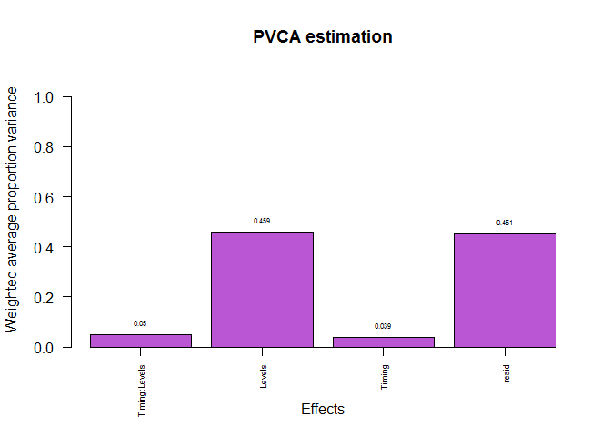

Figura 23. Diagrama de barras con la estimación PVCA

### Detección de genes más variables

El siguiente paso es determinar qué porcentaje de genes muestra una variabilidad que se puede atribuir a causas que no sean por variación aleatoria, ya que si un gen se expresa de manera diferencial, la varianza general del gen será mayor que la de los genes que no muestran una expresión diferencial. Para ello, se representan las desviaciones estándar de los genes, ordenados de menor a mayor.

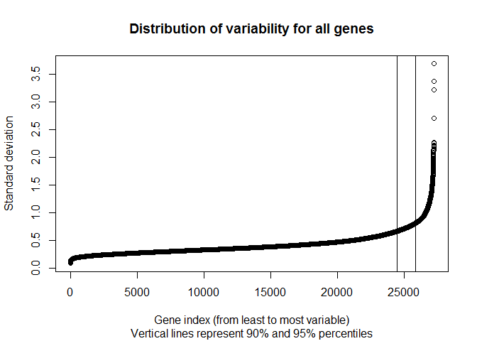

Figura 24. Distribución de la variabilidad de todos los genes

La figura 24 muestra los genes más variables, que son aquellos que tienen una desviación superior al 90-95% de todas las desviaciones estándar.

### Filtraje

```
## $numDupsRemoved
## [1] 86
##
## $numLowVar
## [1] 13890
##
## $numRemoved.ENTREZID
## [1] 8583
```

```
## ExpressionSet (storageMode: lockedEnvironment)
## assayData: 4630 features, 24 samples
##   element names: exprs
## protocolData
##   rowNames: D3.NONE.1 D3.NONE.2 ... D11.1.3 (24 total)
##   varLabels: exprs dates
##   varMetadata: labelDescription channel
## phenoData
##   rowNames: 1 2 ... 24 (24 total)
##   varLabels: FileName Group ... ShortName (5 total)
##   varMetadata: labelDescription channel
## featureData: none
## experimentData: use 'experimentData(object)'
## Annotation: clariomdhumantranscriptcluster.db
```

Después del filtraje, se observa que quedan 4630 genes para analizar.

### Matriz de diseño

Una vez está listo el *expression set*, se procede a construir un modelo lineal para seleccionar aquellos genes que están diferencialmente expresados.

En primer lugar, se crea la matriz de diseño, es decir, una tabla que describa la asignación de cada muestra a una condición experimental. Debe tener tantas filas como muestras y tantas columnas como grupos. Se indica con un 1 si la muestra pertenece al grupo y con un 0 si la muestra no pertenece al grupo. Para crearla, se usa el paquete *limma* y la función *model.Matrix*.

```
##    D11.1 D11.NONE D3.1 D3.NONE D7.01 D7.1 D7.10 D7.NONE
## 1      0        0    0       1     0    0     0       0
## 2      0        0    0       1     0    0     0       0
## 3      0        0    0       1     0    0     0       0
## 4      0        0    0       0     0    0     0       1
## 5      0        0    0       0     0    0     0       1
## 6      0        0    0       0     0    0     0       1
## 7      0        1    0       0     0    0     0       0
## 8      0        1    0       0     0    0     0       0
## 9      0        1    0       0     0    0     0       0
## 10     0        0    1       0     0    0     0       0
## 11     0        0    1       0     0    0     0       0
## 12     0        0    1       0     0    0     0       0
## 13     0        0    0       0     1    0     0       0
## 14     0        0    0       0     1    0     0       0
## 15     0        0    0       0     1    0     0       0
## 16     0        0    0       0     0    1     0       0
## 17     0        0    0       0     0    1     0       0
## 18     0        0    0       0     0    1     0       0
## 19     0        0    0       0     0    0     1       0
## 20     0        0    0       0     0    0     1       0
## 21     0        0    0       0     0    0     1       0
## 22     1        0    0       0     0    0     0       0
## 23     1        0    0       0     0    0     0       0
## 24     1        0    0       0     0    0     0       0
## attr(,"assign")
## [1] 1 1 1 1 1 1 1 1
## attr(,"contrasts")
## attr(,"contrasts")$Group
## [1] "contr.treatment"
```

### Matriz de contraste

La matriz de contraste se usa para describir los contrastes y comparaciones que se quieren realizar entre grupos. Esta matriz tiene tantas columnas como comparaciones y tantas filas como grupos. Se representa con los valores -1 y 1 en aquellos casos que se comparan y un 0 para el resto.

En este estudio, se realizan las siguientes comparaciones:

- **D3.NONE y D7.NONE**: se compara el efecto que tiene el tiempo de exposición (tres y siete días) en los casos en que no se ha suministrado progesterona extra.
- **D3.NONE y D11.NONE**: se compara el efecto que tiene el tiempo de exposición (tres y once días) en los casos en que no se ha suministrado progesterona extra.
- **D3.NONE y D3.1**: se compara el efecto que tiene el suministro de 1 microM de progesterona durante tres días con el efecto que tiene si no se suministra.
- **D7.01 y D7.1**: se compara el efecto que tiene el suministro de 0.1 microM de progesterona y el suministro de 1 microM de progesterona durante siete días.
- **D7.01 y D7.10**: se compara el efecto que tiene el suministro de 0.1 microM de progesterona y el suministro de 10 microM de progesterona durante siete días.
- **D7.1 y D11.1**: se compara el efecto que tiene el suministro de 1 microM de progesterona durante siete y once días.

```
##           Contrasts
## Levels     D3vsD7.NONE D3vsD11.NONE D3.NONEvs1 D7.01vs1 D7.01vs10 D7vsD11.1
##   D11.1              0            0          0        0         0         1
##   D11.NONE           0            1          0        0         0         0
##   D3.1               0            0          1        0         0         0
##   D3.NONE           -1           -1         -1        0         0         0
##   D7.01              0            0          0       -1        -1         0
##   D7.1               0            0          0        1         0        -1
##   D7.10              0            0          0        0         1         0
##   D7.NONE            1            0          0        0         0         0
```

### Estimación del modelo y selección de genes

Después de la realización de la matriz de diseño y de la matriz de contraste, se procede a estimar el modelo y los contrastes, así como realizar las pruebas de significación que servirán para decidir si los genes pueden considerarse diferencialmente expresados.

Para ello se utilizará el análisis implementado en el paquete *limma*, el cual proporciona los valores p ajustados que se usan para ordenar los genes de más a menos, en lo que de expresión diferencial se refiere. El control de los falsos positivos se realiza ajustando los valores p mediante el método de Bejamini y Hochberg [5].

Toda la información de los resultados es almacenada en un objeto llamado *fit.main*.

### Obtención de las listas de genes diferencialmente expresados

Las listas de los genes expresados diferencialmente se obtienen con la función *topTable* del paquete *limma*. Esta función proporciona una lista de genes ordenados por su valor p, de menor a mayor, que se considera como expresados diferencialmente de más a menos. Para cada gen se proporcionan los siguientes estadísticos:

- *logFC*: diferencia media entre grupos
- *AveExpr*: expresión promedia de todos los genes
- *t*: estadístico t moderado
- *p value*: valor p
- *adj.P.Val*: valor p ajustado según Benjamin y Hochberg
- *B*: estadístico B, que es el *log odds* posterior de ser o no ser diferencialmente expresado

A continuación, se muestran las tablas correspondientes a las siguientes comparaciones. La primera columna de cada tabla contiene el ID del fabricante (Affymetrix) para cada conjunto de sondas.

Tabla 2. Comparación D3vsD7.NONE

|  | logFC | AveExpr | t | P.Value | adj.P.Val | B |
| --- | --- | --- | --- | --- | --- | --- |
| TC0100011022.hg.1 | 1.894210 | 8.353534 | 7.820705 | 1.0e-07 | 0.0004621 | 7.452856 |
| TC0400011408.hg.1 | 3.320215 | 6.806726 | 7.577673 | 2.0e-07 | 0.0004621 | 7.022215 |
| TC1800006675.hg.1 | 1.712243 | 7.997384 | 7.162581 | 5.0e-07 | 0.0007311 | 6.264336 |
| TC1500009002.hg.1 | -1.902882 | 6.405849 | -6.559170 | 1.7e-06 | 0.0020067 | 5.112933 |
| TC0100009442.hg.1 | 1.683774 | 6.441448 | 6.074636 | 5.1e-06 | 0.0047065 | 4.147409 |
| TC2000009388.hg.1 | 1.769603 | 6.760931 | 5.859448 | 8.3e-06 | 0.0055124 | 3.707651 |

Tabla 3. Comparación D3vsD11.NONE

|  | logFC | AveExpr | t | P.Value | adj.P.Val | B |
| --- | --- | --- | --- | --- | --- | --- |
| TC2000009388.hg.1 | 3.346783 | 6.760931 | 11.081749 | 0 | 8.0e-07 | 13.38464 |
| TC0100011022.hg.1 | 2.626688 | 8.353534 | 10.844920 | 0 | 8.0e-07 | 13.02789 |
| TC1700006524.hg.1 | 2.761251 | 9.425814 | 10.838281 | 0 | 8.0e-07 | 13.01779 |
| TC0400011408.hg.1 | 4.391828 | 6.806726 | 10.023399 | 0 | 1.8e-06 | 11.73520 |
| TC0500008736.hg.1 | 3.422050 | 9.904925 | 10.012607 | 0 | 1.8e-06 | 11.71763 |
| TC1100012155.hg.1 | 2.799327 | 8.846035 | 9.078628 | 0 | 8.2e-06 | 10.13693 |

Tabla 4. Comparación D3.NONEvs1

|  | logFC | AveExpr | t | P.Value | adj.P.Val | B |
| --- | --- | --- | --- | --- | --- | --- |
| TC0100011022.hg.1 | 6.075458 | 8.353534 | 25.08400 | 0 | 0 | 28.25968 |
| TC0700007434.hg.1 | 7.008988 | 9.000868 | 24.27414 | 0 | 0 | 27.70184 |
| TC0600011037.hg.1 | 7.414875 | 7.855175 | 23.19786 | 0 | 0 | 26.92186 |
| TC1700006909.hg.1 | 5.230017 | 8.070172 | 22.40310 | 0 | 0 | 26.31570 |
| TC0400007520.hg.1 | 5.264614 | 6.128152 | 20.33184 | 0 | 0 | 24.60288 |
| TC0300013469.hg.1 | 6.989899 | 8.367207 | 19.03237 | 0 | 0 | 23.41884 |

Tabla 5. Comparación D7.01vs1

|  | logFC | AveExpr | t | P.Value | adj.P.Val | B |
| --- | --- | --- | --- | --- | --- | --- |
| TC0100013246.hg.1 | 1.230267 | 8.292405 | 4.628004 | 0.0001463 | 0.4350284 | -2.533030 |
| TC0100009442.hg.1 | -1.253635 | 6.441448 | -4.522802 | 0.0001879 | 0.4350284 | -2.590915 |
| TC0500007761.hg.1 | -1.265501 | 7.274850 | -4.243618 | 0.0003657 | 0.4455009 | -2.749396 |
| TC1200010022.hg.1 | -1.307646 | 4.605715 | -4.154207 | 0.0004527 | 0.4455009 | -2.801587 |
| TC0400007836.hg.1 | 1.352985 | 6.059355 | 4.128741 | 0.0004811 | 0.4455009 | -2.816574 |
| TC0200016502.hg.1 | 1.155634 | 3.348672 | 3.819767 | 0.0010048 | 0.7753787 | -3.002462 |

Tabla 6. Comparación D7.01vs10

|  | logFC | AveExpr | t | P.Value | adj.P.Val | B |
| --- | --- | --- | --- | --- | --- | --- |
| TC0600011777.hg.1 | 2.504243 | 5.532911 | 9.765222 | 0e+00 | 1.41e-05 | 10.981722 |
| TC1700007557.hg.1 | -2.025065 | 8.250665 | -8.872237 | 0e+00 | 3.62e-05 | 9.536974 |
| TC0500007761.hg.1 | -2.542453 | 7.274850 | -8.525633 | 0e+00 | 3.91e-05 | 8.944087 |
| TC0X00009025.hg.1 | 2.272713 | 5.604722 | 8.461475 | 0e+00 | 3.91e-05 | 8.832323 |
| TC1400008705.hg.1 | 2.331046 | 7.617961 | 8.353166 | 0e+00 | 3.91e-05 | 8.642208 |
| TC0400010733.hg.1 | 2.643489 | 4.274981 | 8.238974 | 1e-07 | 4.08e-05 | 8.439801 |

Tabla 7. Comparación D7vsD11.1

|  | logFC | AveExpr | t | P.Value | adj.P.Val | B |
| --- | --- | --- | --- | --- | --- | --- |
| TC1000011370.hg.1 | -2.715616 | 10.450450 | -7.964813 | 1.0e-07 | 0.0004214 | 7.737424 |
| TC1100009169.hg.1 | -1.929613 | 10.130214 | -7.415930 | 3.0e-07 | 0.0006453 | 6.757608 |
| TC0200011219.hg.1 | 2.031339 | 5.446987 | 7.197566 | 4.0e-07 | 0.0006792 | 6.354169 |
| TC1400010772.hg.1 | -1.896531 | 6.315658 | -6.690929 | 1.3e-06 | 0.0014815 | 5.388572 |
| TC0900011441.hg.1 | 2.132374 | 4.648786 | 6.558419 | 1.7e-06 | 0.0014815 | 5.129329 |
| TC0100013246.hg.1 | 1.731262 | 8.292405 | 6.512638 | 1.9e-06 | 0.0014815 | 5.039132 |

### Anotación de genes

A continuación, se procede a realizar la anotación de genes, es decir, a buscar información y asociar cada identificador de la correspondiente sonda o tránscrito con un nombre más familiar como el símbolo del gen, el identificador del gen Entrez o la descripción del gen.

Para ello, se crea una función que se llamará *annotatedTopTable*.

A continuación, se muestran las tablas de las comparaciones del estudio.

Tabla 7. Comparación D3vsD7.NONE

| PROBEID | SYMBOL | ENTREZID | GENENAME | logFC | AveExpr | t | P.Value | adj.P.Val | B |
| --- | --- | --- | --- | --- | --- | --- | --- | --- | --- |
| TC0100006486.hg.1 | AGRN | 375790 | agrin | 0.0442065 | 7.553981 | 0.1125831 | 0.9114347 | 0.9998621 | -6.122118 |
| TC0100006683.hg.1 | HES3 | 390992 | hes family bHLH transcription factor 3 | 0.1944571 | 5.563278 | 0.4712112 | 0.6423684 | 0.9998621 | -6.018149 |
| TC0100006725.hg.1 | PER3 | 8863 | period circadian regulator 3 | 0.0367143 | 6.924883 | 0.1384402 | 0.8912170 | 0.9998621 | -6.118879 |
| TC0100006729.hg.1 | PARK7 | 11315 | Parkinsonism associated deglycase | -0.0056915 | 10.009541 | -0.0154706 | 0.9878034 | 0.9998621 | -6.128328 |
| TC0100006773.hg.1 | SPSB1 | 80176 | splA/ryanodine receptor domain and SOCS box containing 1 | -0.3484666 | 8.754389 | -1.0939421 | 0.2864212 | 0.9998621 | -5.547926 |
| TC0100006787.hg.1 | PIK3CD | 5293 | phosphatidylinositol-4,5-bisphosphate 3-kinase catalytic subunit delta | -0.2557379 | 7.243565 | -0.7154725 | 0.4822296 | 0.9998621 | -5.875972 |

Tabla 8. Comparación D3vsD11.NONE

| PROBEID | SYMBOL | ENTREZID | GENENAME | logFC | AveExpr | t | P.Value | adj.P.Val | B |
| --- | --- | --- | --- | --- | --- | --- | --- | --- | --- |
| TC0100006486.hg.1 | AGRN | 375790 | agrin | 0.0721952 | 7.553981 | 0.1838637 | 0.8558915 | 0.9998360 | -6.561076 |
| TC0100006683.hg.1 | HES3 | 390992 | hes family bHLH transcription factor 3 | 0.0046740 | 5.563278 | 0.0113260 | 0.9910707 | 0.9998360 | -6.578372 |
| TC0100006725.hg.1 | PER3 | 8863 | period circadian regulator 3 | 0.2855836 | 6.924883 | 1.0768634 | 0.2938075 | 0.9175301 | -5.998640 |
| TC0100006729.hg.1 | PARK7 | 11315 | Parkinsonism associated deglycase | -0.2388875 | 10.009541 | -0.6493448 | 0.5231840 | 0.9998360 | -6.363912 |
| TC0100006773.hg.1 | SPSB1 | 80176 | splA/ryanodine receptor domain and SOCS box containing 1 | 0.2086848 | 8.754389 | 0.6551247 | 0.5195294 | 0.9998360 | -6.360115 |
| TC0100006787.hg.1 | PIK3CD | 5293 | phosphatidylinositol-4,5-bisphosphate 3-kinase catalytic subunit delta | -0.4095212 | 7.243565 | -1.1457090 | 0.2648576 | 0.8753981 | -5.924465 |

Tabla 9. Comparación D3.NONEvs1

| PROBEID | SYMBOL | ENTREZID | GENENAME | logFC | AveExpr | t | P.Value | adj.P.Val | B |
| --- | --- | --- | --- | --- | --- | --- | --- | --- | --- |
| TC0100006486.hg.1 | AGRN | 375790 | agrin | -0.2823962 | 7.553981 | -0.7191947 | 0.4799812 | 0.6781172 | -6.7367911 |
| TC0100006683.hg.1 | HES3 | 390992 | hes family bHLH transcription factor 3 | -0.0247228 | 5.563278 | -0.0599086 | 0.9527972 | 0.9781488 | -7.0004182 |
| TC0100006725.hg.1 | PER3 | 8863 | period circadian regulator 3 | -0.6446429 | 6.924883 | -2.4307846 | 0.0241521 | 0.0758624 | -4.3009460 |
| TC0100006729.hg.1 | PARK7 | 11315 | Parkinsonism associated deglycase | -0.3997324 | 10.009541 | -1.0865540 | 0.2895998 | 0.4945724 | -6.4056019 |
| TC0100006773.hg.1 | SPSB1 | 80176 | splA/ryanodine receptor domain and SOCS box containing 1 | 1.2744765 | 8.754389 | 4.0009674 | 0.0006526 | 0.0040287 | -0.8424217 |
| TC0100006787.hg.1 | PIK3CD | 5293 | phosphatidylinositol-4,5-bisphosphate 3-kinase catalytic subunit delta | -0.6021108 | 7.243565 | -1.6845127 | 0.1069501 | 0.2451380 | -5.6202749 |

Tabla 10. Comparación D7.01vs1

| PROBEID | SYMBOL | ENTREZID | GENENAME | logFC | AveExpr | t | P.Value | adj.P.Val | B |
| --- | --- | --- | --- | --- | --- | --- | --- | --- | --- |
| TC0100006486.hg.1 | AGRN | 375790 | agrin | -0.0954347 | 7.553981 | -0.2430491 | 0.8103354 | 0.9999619 | -4.817508 |
| TC0100006683.hg.1 | HES3 | 390992 | hes family bHLH transcription factor 3 | -0.0664996 | 5.563278 | -0.1611427 | 0.8735276 | 0.9999619 | -4.823968 |
| TC0100006725.hg.1 | PER3 | 8863 | period circadian regulator 3 | -0.0879075 | 6.924883 | -0.3314770 | 0.7435830 | 0.9999619 | -4.807628 |
| TC0100006729.hg.1 | PARK7 | 11315 | Parkinsonism associated deglycase | 0.0948281 | 10.009541 | 0.2577621 | 0.7991100 | 0.9999619 | -4.816073 |
| TC0100006773.hg.1 | SPSB1 | 80176 | splA/ryanodine receptor domain and SOCS box containing 1 | 0.1411344 | 8.754389 | 0.4430637 | 0.6622690 | 0.9999619 | -4.790908 |
| TC0100006787.hg.1 | PIK3CD | 5293 | phosphatidylinositol-4,5-bisphosphate 3-kinase catalytic subunit delta | 0.2445418 | 7.243565 | 0.6841493 | 0.5013926 | 0.9999619 | -4.739056 |

Tabla 11. Comparación D7.01vs10

| PROBEID | SYMBOL | ENTREZID | GENENAME | logFC | AveExpr | t | P.Value | adj.P.Val | B |
| --- | --- | --- | --- | --- | --- | --- | --- | --- | --- |
| TC0100006486.hg.1 | AGRN | 375790 | agrin | -0.4397461 | 7.553981 | -1.1199268 | 0.2754428 | 0.9995941 | -5.695604 |
| TC0100006683.hg.1 | HES3 | 390992 | hes family bHLH transcription factor 3 | -0.2216149 | 5.563278 | -0.5370203 | 0.5969216 | 0.9995941 | -6.167413 |
| TC0100006725.hg.1 | PER3 | 8863 | period circadian regulator 3 | -0.0686982 | 6.924883 | -0.2590436 | 0.7981344 | 0.9995941 | -6.278636 |
| TC0100006729.hg.1 | PARK7 | 11315 | Parkinsonism associated deglycase | 0.0291517 | 10.009541 | 0.0792402 | 0.9375949 | 0.9995941 | -6.309420 |
| TC0100006773.hg.1 | SPSB1 | 80176 | splA/ryanodine receptor domain and SOCS box containing 1 | 0.2273906 | 8.754389 | 0.7138480 | 0.4832129 | 0.9995941 | -6.057431 |
| TC0100006787.hg.1 | PIK3CD | 5293 | phosphatidylinositol-4,5-bisphosphate 3-kinase catalytic subunit delta | 0.0930934 | 7.243565 | 0.2604455 | 0.7970674 | 0.9995941 | -6.278268 |

Tabla 12. Comparación D7vsD11.1

| PROBEID | SYMBOL | ENTREZID | GENENAME | logFC | AveExpr | t | P.Value | adj.P.Val | B |
| --- | --- | --- | --- | --- | --- | --- | --- | --- | --- |
| TC0100006486.hg.1 | AGRN | 375790 | agrin | -0.1491839 | 7.553981 | -0.3799353 | 0.7078246 | 0.9998381 | -6.076750 |
| TC0100006683.hg.1 | HES3 | 390992 | hes family bHLH transcription factor 3 | -0.0652992 | 5.563278 | -0.1582339 | 0.8757905 | 0.9998381 | -6.136212 |
| TC0100006725.hg.1 | PER3 | 8863 | period circadian regulator 3 | 0.3570908 | 6.924883 | 1.3464990 | 0.1925552 | 0.9998381 | -5.280198 |
| TC0100006729.hg.1 | PARK7 | 11315 | Parkinsonism associated deglycase | 0.0838383 | 10.009541 | 0.2278895 | 0.8219455 | 0.9998381 | -6.122777 |
| TC0100006773.hg.1 | SPSB1 | 80176 | splA/ryanodine receptor domain and SOCS box containing 1 | -0.5903068 | 8.754389 | -1.8531516 | 0.0780246 | 0.7832175 | -4.563032 |
| TC0100006787.hg.1 | PIK3CD | 5293 | phosphatidylinositol-4,5-bisphosphate 3-kinase catalytic subunit delta | 0.0469902 | 7.243565 | 0.1314634 | 0.8966653 | 0.9998381 | -6.140089 |

### Visualización de la expresión diferencial

La visualización de los genes expresados diferencialmente se realiza mediante los gráficos de volcanes. En el eje X de estos gráficos se observan los cambios de expresión en escala logarítmica y en el gráfico Y se representa el ‘menos logaritmo’ del valor p o, alternativamente, el estadístico B.

Los genes cuyo *log odds* es superior a 0 y cuyo *log fold change* es, en valor absoluto, superior a 1, pueden considerarse candidatos a estar diferencialmente expresados.

A continuación, se representan los gráficos de las varias comparaciones. Se muestran, en cada uno, los genes principales, es decir, los más diferencialmente expresados.

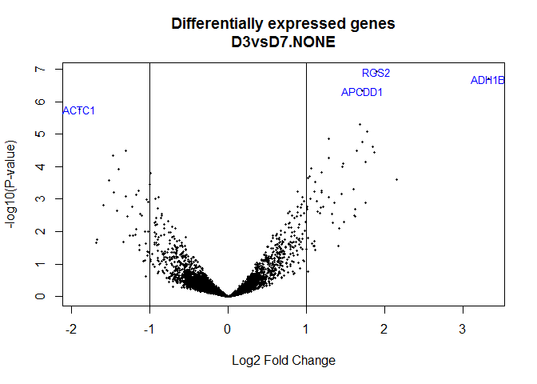

Figura 25. Volcano plot comparación D3vsD7.NONE

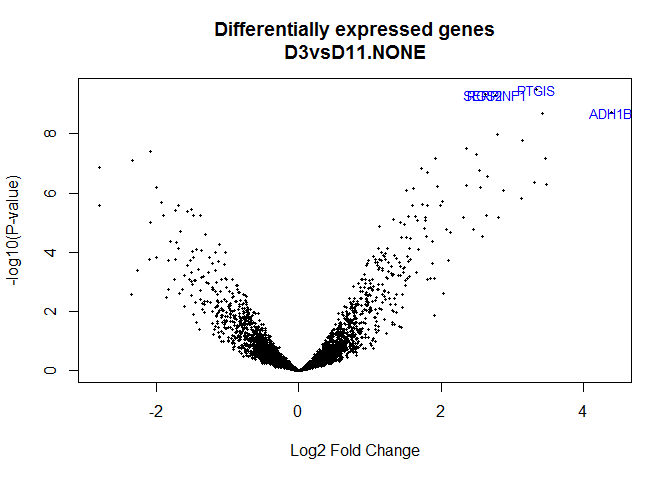

Figura 26. Volcano plot comparación D3vsD11.NONE

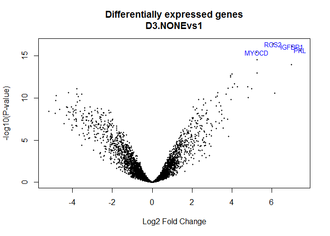

Figura 27. Volcano plot comparación D3.NONEvs1

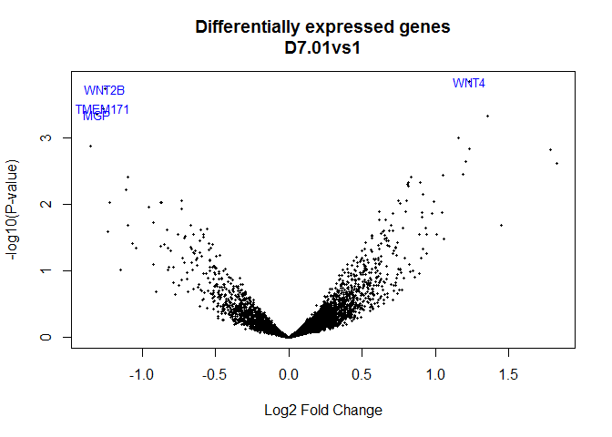

Figura 28. Volcano plot comparación D7.01vs1

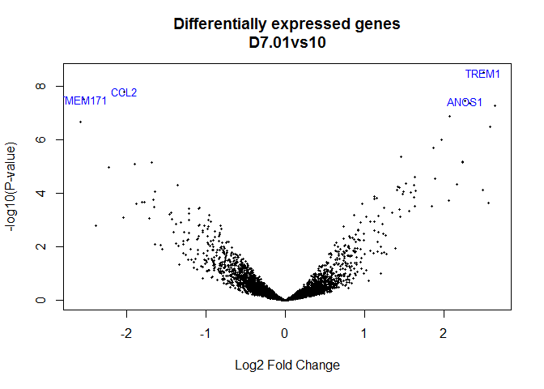

Figura 29. Volcano plot comparación D7.01vs10

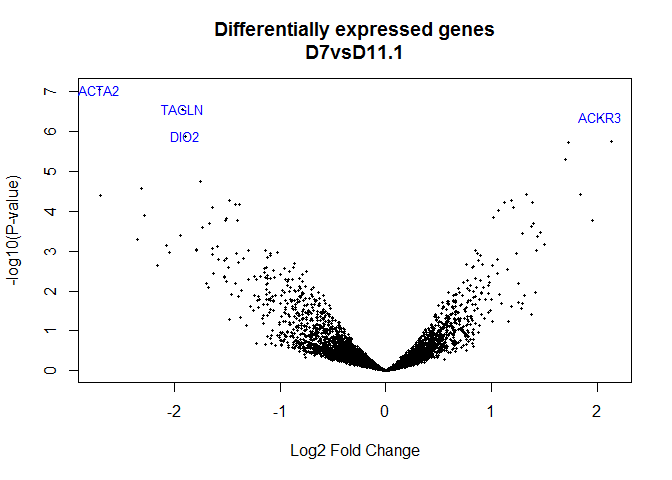

Figura 30. Volcano plot comparación D7vsD11.1